# Taller 31 de octubre: resumen y dimensiones para su cliente

Gerencia de Riesgo de Crédito · Componentes principales y análisis factorial

Oscar Manuel Contreras Gacha (20221020052)

Juan Pablo Sarmiento Ramírez (20221020138)

Steven Navarro Parrales (20221020048)

Juan Diego Grajales Castillo (20221020128)

Estadística Multidimensional · 26158 · grupo 020-81 · periodo 2026-3

Cada resultado se lee con tres frases:

- 👀 **Qué vemos**: el número o el gráfico, sin interpretar.
- 💼 **Qué significa para el cliente**: la traducción a la cartera de tarjetas.
- ✅ **Qué decide el cliente**: la consecuencia práctica.

# 1 El encargo

```r
vars <- c("Annual_Income", "Credit_Limit", "Statement_Balance", "Payment_Amount",
          "EMI_Count", "Monthly_Transactions", "Avg_Transaction_Value",
          "International_Transactions", "Credit_Score")
suplementarias <- c("Payment_Ratio", "Credit_Utilization")   # NO construyen nada: solo ayudan a leer
dinero <- c("Annual_Income", "Credit_Limit", "Statement_Balance", "Payment_Amount")
uso    <- c("EMI_Count", "Monthly_Transactions", "Avg_Transaction_Value", "International_Transactions")

etiqueta <- c(Annual_Income = "Ingreso anual", Credit_Limit = "Cupo",
              Statement_Balance = "Saldo facturado", Payment_Amount = "Monto pagado",
              EMI_Count = "Compras a cuotas", Monthly_Transactions = "Compras al mes",
              Avg_Transaction_Value = "Valor por compra",
              International_Transactions = "Compras internacionales",
              Credit_Score = "Puntaje crediticio",
              Payment_Ratio = "Proporción pagada", Credit_Utilization = "Uso del cupo")
bloque <- c(setNames(rep("Dinero", 4), dinero), setNames(rep("Uso de la tarjeta", 4), uso),
            Credit_Score = "Puntaje")
p <- length(vars)
```

```r
ruta <- c("data/bronze/synthetic_credit_card_customer_behavior_dataset.csv",
          "../data/bronze/synthetic_credit_card_customer_behavior_dataset.csv")
ruta <- ruta[file.exists(ruta)][1]
if (is.na(ruta)) stop("No se encuentra el CSV: ajuste la ruta en este bloque.")
credit <- read.csv(ruta, stringsAsFactors = FALSE)

# Identificador del cliente (para citar casos concretos). Si la base no trae uno, se usa el número de fila.
col_id <- intersect(c("Customer_ID", "CustomerID", "Customer_Id", "customer_id", "Client_ID", "ID", "Id"),
                    names(credit))[1]
credit$id_cliente <- if (is.na(col_id)) seq_len(nrow(credit)) else credit[[col_id]]
```

**El cliente es la Gerencia de Riesgo de Crédito del banco emisor** de las 50 000 tarjetas de la base (rupias indias, ₹). Cada mes **decide qué clientes entran al programa de seguimiento preventivo** (llamada del gestor, congelar los aumentos de cupo y ofrecer refinanciación antes de la mora), y hoy lo hace con una ficha de **9 variables numéricas** por cliente: ingreso, cupo, saldo facturado, monto pagado, compras a cuotas, compras al mes, valor por compra, compras internacionales y puntaje crediticio. Esas 9 son **las mismas durante todo el taller** y son las mismas de los talleres anteriores: responden lo que se pregunta un analista de riesgo (cuánto puede, cuánto debe y paga, cómo usa la tarjeta y qué dice el buró). Queremos averiguar **si esa ficha se puede resumir en pocos indicadores, qué se pierde al hacerlo y si detrás de las variables hay dimensiones que el cliente pueda interpretar y que sean estables**. `Payment_Ratio` (proporción pagada) y `Credit_Utilization` (uso del cupo) quedan **aparte**: no entran al análisis, pero sirven para comprobar si los nombres que propongamos tienen sentido.

# 2 Los datos que entran

## 2.1 Qué casos entran y cuáles quedan por fuera

```r
# --- Limpieza del primer corte (Módulo 2 de Entrega/analisis_synthetic_credit_card.Rmd) ----
# 1. Faltantes: celdas vacías (is.na) y filas que sobreviven completas (complete.cases)
total_celdas <- prod(dim(credit))
celdas_na <- sum(is.na(credit))
filas_completas <- sum(complete.cases(credit))
faltantes_por_col <- colSums(is.na(credit))
# 2. Duplicados: filas idénticas en todas las columnas e identificadores repetidos
n_duplicados_filas <- sum(duplicated(credit))
n_duplicados_id <- sum(duplicated(credit$Customer_ID))
# 3. Rangos de las reglas de negocio (valores imposibles o códigos de faltante)
rango_edad <- range(credit$Age)
rango_pr <- range(credit$Payment_Ratio)
rango_cu <- range(credit$Credit_Utilization)

c(celdas_vacias = celdas_na, filas_completas = filas_completas,
  filas_duplicadas = n_duplicados_filas, Customer_ID_repetidos = n_duplicados_id)
```

```
##         celdas_vacias       filas_completas      filas_duplicadas
##                     0                 50000                     0
## Customer_ID_repetidos
##                     0
```

```r
faltantes_por_col[faltantes_por_col > 0]          # vacío si ninguna columna tiene NA
```

```
## named numeric(0)
```

```r
rbind(Age = rango_edad, Payment_Ratio = rango_pr, Credit_Utilization = rango_cu)
```

```
##                    [,1]  [,2]
## Age                18.0 70.00
## Payment_Ratio       0.1  1.00
## Credit_Utilization  0.1  0.95
```

```r
# --- Casos que entran a este taller (las 9 variables) ---------------------------------------
n_inicial <- nrow(credit)

vacias_antes <- sapply(credit[vars], function(x) sum(is.na(x) | trimws(as.character(x)) == ""))
credit[vars] <- lapply(credit[vars], function(x) suppressWarnings(as.numeric(x)))  # lo no numérico pasa a NA
vacias_despues <- sapply(credit[vars], function(x) sum(is.na(x)))

completos   <- complete.cases(credit[vars])
n_completos <- sum(completos)
n_fuera     <- n_inicial - n_completos

data.frame(concepto = c("Casos iniciales", "Casos con información completa en las 9 variables",
                        "Casos que quedan por fuera"),
           clientes = miles(c(n_inicial, n_completos, n_fuera)))
```

| concepto | clientes |
| --- | --- |
| Casos iniciales | 50 000 |
| Casos con información completa en las 9 variables | 50 000 |
| Casos que quedan por fuera | 0 |

```r
# Por qué quedaría alguien por fuera: celdas vacías o no numéricas, variable por variable
data.frame(variable = etiqueta[vars],
           vacias_en_el_archivo = vacias_antes,
           no_numericas_convertidas_a_vacio = vacias_despues - vacias_antes,
           valores_negativos = sapply(credit[vars], function(x) sum(x < 0, na.rm = TRUE)),
           row.names = NULL)
```

| variable | vacias_en_el_archivo | no_numericas_convertidas_a_vacio | valores_negativos |
| --- | --- | --- | --- |
| Ingreso anual | 0 | 0 | 0 |
| Cupo | 0 | 0 | 0 |
| Saldo facturado | 0 | 0 | 0 |
| Monto pagado | 0 | 0 | 0 |
| Compras a cuotas | 0 | 0 | 0 |
| Compras al mes | 0 | 0 | 0 |
| Valor por compra | 0 | 0 | 0 |
| Compras internacionales | 0 | 0 | 0 |
| Puntaje crediticio | 0 | 0 | 0 |

```r
# Verificación adicional (se reporta, no se elimina): filas idénticas en las 9 variables
c(filas_repetidas_en_las_9_variables = sum(duplicated(credit[vars])))
```

```
## filas_repetidas_en_las_9_variables
##                                  0
```

```r
datos <- credit[completos, ]
```

- 👀 **Qué vemos:** la base trae 50 000 clientes; 50 000 tienen las 9 variables completas y 0 quedan por fuera. Ninguno se excluye: no hay celdas vacías ni valores no numéricos en estas variables. La auditoría del primer corte tampoco encontró filas duplicadas (0), identificadores repetidos (0) ni valores imposibles: la edad va de 18 a 70 años y la proporción pagada y el uso del cupo están entre 0 y 1.
- 💼 **Qué significa para el cliente:** el análisis habla de la cartera completa que la Gerencia tiene en la base (50 000 tarjetas).
- ✅ **Qué decide el cliente:** puede leer los resultados como válidos para esos 50 000 clientes; no hay casos escondidos.

## 2.2 ¿Debemos estandarizar?

```r
skew <- function(x) mean(((x - mean(x)) / sd(x))^3)
asimetria <- sapply(datos[vars], skew)
con_log <- vars[abs(asimetria) > 1]          # la regla del Módulo 11: log(x+1) si |asimetría| > 1

X <- datos[vars]
X[con_log] <- lapply(X[con_log], log1p)

unidad <- c(Annual_Income = "₹", Credit_Limit = "₹", Statement_Balance = "₹", Payment_Amount = "₹",
            EMI_Count = "número", Monthly_Transactions = "número", Avg_Transaction_Value = "₹",
            International_Transactions = "número", Credit_Score = "puntos")
sd_orig <- sapply(datos[vars], sd)
sd_log  <- sapply(X, sd)

data.frame(variable = etiqueta[vars], unidad = unidad[vars],
           asimetria = round(asimetria, 2),
           entra_con_log = ifelse(vars %in% con_log, "sí", "no"),
           desviacion_original = coma(sd_orig, 2),
           desviacion_despues_del_log = coma(sd_log, 2),
           row.names = NULL) |>
  arrange(desc(sd_orig))
```

| variable | unidad | asimetria | entra_con_log | desviacion_original | desviacion_despues_del_log |
| --- | --- | --- | --- | --- | --- |
| Ingreso anual | ₹ | 2.55 | sí | 1 407 257,48 | 0,80 |
| Cupo | ₹ | 3.01 | sí | 1 009 854,42 | 1,18 |
| Saldo facturado | ₹ | 3.80 | sí | 559 547,63 | 1,18 |
| Monto pagado | ₹ | 4.20 | sí | 453 396,64 | 1,27 |
| Valor por compra | ₹ | 3.90 | sí | 779,59 | 0,62 |
| Puntaje crediticio | puntos | -0.58 | no | 68,44 | 68,44 |
| Compras al mes | número | 0.54 | no | 42,05 | 42,05 |
| Compras internacionales | número | 2.11 | sí | 2,60 | 0,77 |
| Compras a cuotas | número | 0.17 | no | 1,67 | 1,67 |

```r
pca_sin <- prcomp(X)                  # sin estandarizar (con log)
pca     <- prcomp(X, scale. = TRUE)   # estandarizando: nuestra decisión

info_c1 <- function(pc) 100 * pc$sdev[1]^2 / sum(pc$sdev^2)
manda   <- function(pc) etiqueta[names(which.max(abs(pc$rotation[, 1])))]

data.frame(version = c("Sin estandarizar", "Estandarizando"),
           la_C1_guarda_de_cada_100 = round(c(info_c1(pca_sin), info_c1(pca)), 1),
           variable_que_mas_pesa_en_C1 = c(manda(pca_sin), manda(pca)),
           su_peso = round(c(max(abs(pca_sin$rotation[, 1])), max(abs(pca$rotation[, 1]))), 2))
```

|  | version | la_C1_guarda_de_cada_100 | variable_que_mas_pesa_en_C1 | su_peso |
| --- | --- | --- | --- | --- |
| Credit_Score | Sin estandarizar | 72.5 | Puntaje crediticio | 1.00 |
| Credit_Limit | Estandarizando | 64.3 | Cupo | 0.41 |

**Decisión: estandarizamos.** Las variables vienen en unidades que no se pueden comparar (rupias, conteos y puntos): en la escala original la desviación va de 1,67 a 1 407 257, y aun con el logaritmo va de 0,62 a 68,44.

- 👀 **Qué vemos:** sin estandarizar, la primera componente guarda 72,5 de cada 100 partes de la información, pero casi todo su peso está en puntaje crediticio (peso 1,00); estandarizando guarda 64,3 y ninguna variable manda sola.
- 💼 **Qué significa para el cliente:** si no se estandariza, el resumen copia a la variable de números más grandes y no a lo que distingue a los clientes: como los montos ya entran en log, la que tiene los números más grandes es el puntaje crediticio (desviación de 68,44 puntos), y el resultado sería ese puntaje presentado como resumen de toda la ficha.
- ✅ **Qué decide el cliente:** todo lo que sigue se hace con las variables en log (las 6 de cola larga) y estandarizadas; así ninguna manda solo por tener números grandes.

# 3 ¿Se repiten?

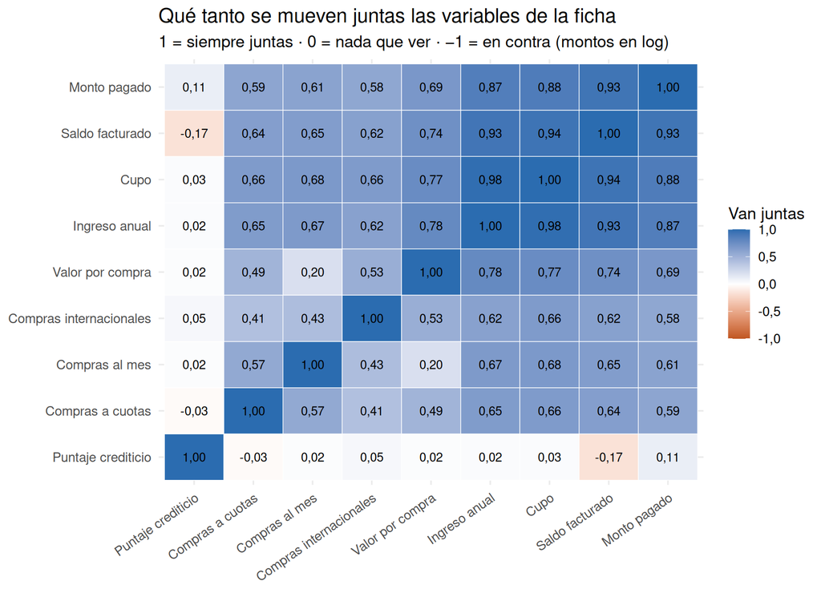

```r
R <- cor(X)
orden <- vars[hclust(as.dist(1 - abs(R)))$order]

as.data.frame(as.table(R)) |>
  mutate(Var1 = factor(etiqueta[as.character(Var1)], levels = etiqueta[orden]),
         Var2 = factor(etiqueta[as.character(Var2)], levels = etiqueta[orden])) |>
  ggplot(aes(Var1, Var2, fill = Freq)) +
  geom_tile(color = "white") +
  geom_text(aes(label = coma(Freq, 2)), size = 3.4) +
  scale_fill_gradient2(low = "#C05621", mid = "white", high = "#2B6CB0", limits = c(-1, 1),
                       name = "Van juntas", labels = function(x) coma(x, 1)) +
  labs(title = "Qué tanto se mueven juntas las variables de la ficha",
       subtitle = "1 = siempre juntas · 0 = nada que ver · −1 = en contra (montos en log)",
       x = NULL, y = NULL) +
  theme(axis.text.x = element_text(angle = 35, hjust = 1))
```

```r
fuera_diag <- R; diag(fuera_diag) <- NA
mayor <- apply(abs(fuera_diag), 1, max, na.rm = TRUE)
sola  <- names(which.min(mayor))

r_din     <- R[dinero, dinero][upper.tri(R[dinero, dinero])]
r_uso_din <- as.vector(R[uso, dinero])
r_uso     <- R[uso, uso][upper.tri(R[uso, uso])]

data.frame(variable = etiqueta[vars], su_mayor_correlacion_con_otra = round(mayor, 2), row.names = NULL) |>
  arrange(su_mayor_correlacion_con_otra)
```

| variable | su_mayor_correlacion_con_otra |
| --- | --- |
| Puntaje crediticio | 0.17 |
| Compras a cuotas | 0.66 |
| Compras internacionales | 0.66 |
| Compras al mes | 0.68 |
| Valor por compra | 0.78 |
| Monto pagado | 0.93 |
| Saldo facturado | 0.94 |
| Ingreso anual | 0.98 |
| Cupo | 0.98 |

- 👀 **Qué vemos:** ingreso, cupo, saldo facturado y monto pagado van muy juntas (correlaciones de 0,87 a 0,98); las cuatro variables de uso de la tarjeta se parecen entre sí entre 0,20 y 0,57 y a las de dinero entre 0,58 y 0,78; y la variable que va por su cuenta es el **puntaje crediticio**: con ninguna pasa de 0,17.
- 💼 **Qué significa para el cliente:** mirar ingreso, cupo, saldo y pago a la vez no le da cuatro señales sino una repetida: **el tamaño del cliente**. Las variables de uso lo acompañan en menor medida, y el puntaje crediticio, que es lo que la Gerencia más mira para el riesgo, no se parece a ninguna: dice algo que el tamaño no dice. Por eso **sí tiene sentido resumir** el bloque de dinero y uso en pocos indicadores, y no tiene sentido meter el puntaje en ese mismo resumen sin revisar.
- ✅ **Qué decide el cliente:** puede acortar la ficha en el bloque de dinero (ingreso y cupo bastan para leer el tamaño), pero debe conservar el puntaje como variable aparte.

# 4 El resumen con componentes principales

```r
# prcomp() entrega cada componente con un signo arbitrario; lo fijamos con una variable ancla:
#   C1: el cupo pesa positivo  ·  C2: el puntaje pesa NEGATIVO (arriba = peor puntaje)  ·  C3: valor por compra positivo
signo <- c(sign(pca$rotation["Credit_Limit", 1]),
           -sign(pca$rotation["Credit_Score", 2]),
            sign(pca$rotation["Avg_Transaction_Value", 3]))
pesos <- sweep(pca$rotation[, 1:3], 2, signo, `*`)
sc    <- sweep(pca$x[, 1:3], 2, signo, `*`)
colnames(sc) <- c("C1", "C2", "C3")

reparto <- data.frame(componente = factor(paste0("C", 1:p), levels = paste0("C", 1:p)),
                      de_cada_100 = 100 * pca$sdev^2 / sum(pca$sdev^2))
reparto$acumulado <- cumsum(reparto$de_cada_100)
k1 <- reparto$de_cada_100[1]
k2 <- reparto$acumulado[2]
k3 <- reparto$acumulado[3]
k80 <- which(reparto$acumulado > 80)[1]

# El grupo que le importa a la Gerencia: el 20 % de peor puntaje
riesgo <- datos$Credit_Score <= quantile(datos$Credit_Score, 0.20)
en_el_20_alto <- function(s) s >= quantile(s, 0.80)
# Para darle a cada componente su mejor oportunidad se prueban los dos extremos y se deja el que más encuentra
encuentra <- function(s, objetivo = riesgo) max(sum(objetivo & en_el_20_alto(s)), sum(objetivo & en_el_20_alto(-s)))
enc <- sapply(1:3, function(j) encuentra(sc[, j]))
```

## 4.1 ¿Cuánta información conserva cada componente?

```r
reparto |> mutate(across(c(de_cada_100, acumulado), ~ round(.x, 1)))
```

| componente | de_cada_100 | acumulado |
| --- | --- | --- |
| C1 | 64.3 | 64.3 |
| C2 | 11.7 | 76.0 |
| C3 | 9.3 | 85.3 |
| C4 | 6.3 | 91.6 |
| C5 | 5.0 | 96.6 |
| C6 | 2.2 | 98.8 |
| C7 | 0.9 | 99.8 |
| C8 | 0.2 | 99.9 |
| C9 | 0.1 | 100.0 |

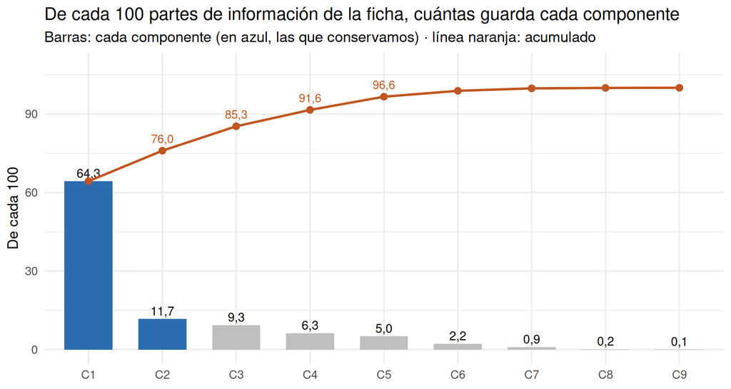

```r
ggplot(reparto, aes(componente, de_cada_100)) +
  geom_col(aes(fill = componente %in% c("C1", "C2")), width = 0.65) +
  geom_text(aes(label = coma(de_cada_100)), vjust = -0.4, size = 3.8) +
  geom_line(aes(y = acumulado, group = 1), color = "#C05621", linewidth = 1) +
  geom_point(aes(y = acumulado), color = "#C05621", size = 2.4) +
  geom_text(data = reparto[2:5, ], aes(y = acumulado, label = coma(acumulado)),
            vjust = -0.9, color = "#C05621", size = 3.6) +
  scale_fill_manual(values = c("TRUE" = "#2B6CB0", "FALSE" = "grey75"), guide = "none") +
  scale_y_continuous(limits = c(0, 108)) +
  labs(title = "De cada 100 partes de información de la ficha, cuántas guarda cada componente",
       subtitle = "Barras: cada componente (en azul, las que conservamos) · línea naranja: acumulado",
       x = NULL, y = "De cada 100")
```

- 👀 **Qué vemos:** la primera componente guarda 64,3 de cada 100 partes de la información, con dos se llega a 76,0 y con tres a 85,3.
- 💼 **Qué significa para el cliente:** **conservamos dos componentes.** No es una regla de porcentaje sino del problema: la primera es el tamaño del cliente y la segunda, como se ve en 4.2, concentra el puntaje y el hábito de pago, que es justo lo que el seguimiento necesita. Una tercera sumaría 9,3 partes y es de estilo de compra; para encontrar a los 10 046 clientes de puntaje bajo, la primera componente encuentra 2 089, la segunda 9 571 y la tercera 2 329 (al azar serían 2 009), así que la tercera no le ayuda a decidir.
- ✅ **Qué decide el cliente:** trabajar con dos números, tamaño y puntaje con hábito de pago, que guardan 76,0 de cada 100 partes de la ficha, y no con uno ni con nueve.

## 4.2 ¿Qué representan las primeras componentes?

```r
data.frame(variable = etiqueta[vars], round(pesos, 2), row.names = NULL)
```

| variable | PC1 | PC2 | PC3 |
| --- | --- | --- | --- |
| Ingreso anual | 0.40 | -0.02 | 0.04 |
| Cupo | 0.41 | -0.02 | 0.03 |
| Saldo facturado | 0.40 | 0.17 | 0.05 |
| Monto pagado | 0.38 | -0.10 | 0.02 |
| Compras a cuotas | 0.30 | 0.07 | -0.30 |
| Compras al mes | 0.29 | 0.01 | -0.72 |
| Valor por compra | 0.32 | -0.04 | 0.60 |
| Compras internacionales | 0.29 | -0.09 | 0.18 |
| Puntaje crediticio | 0.00 | -0.97 | -0.07 |

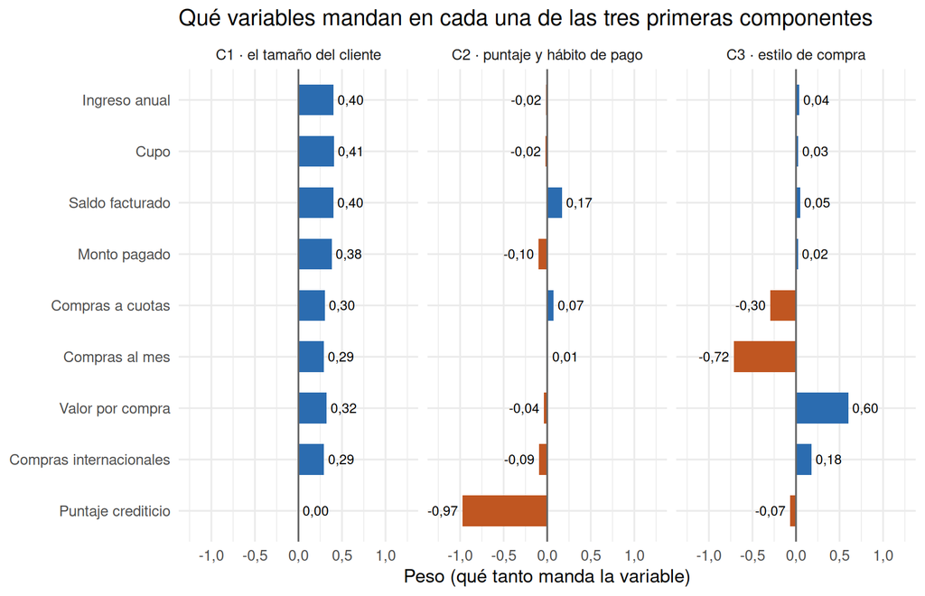

```r
nombres <- c(PC1 = "C1 · el tamaño del cliente", PC2 = "C2 · puntaje y hábito de pago",
             PC3 = "C3 · estilo de compra")
data.frame(pesos, variable = rownames(pesos)) |>
  pivot_longer(-variable, names_to = "componente", values_to = "peso") |>
  mutate(componente = factor(nombres[componente], levels = nombres),
         variable = factor(etiqueta[variable], levels = rev(etiqueta[vars]))) |>
  ggplot(aes(peso, variable, fill = peso > 0)) +
  geom_col(width = 0.6) +
  geom_vline(xintercept = 0, color = "grey40") +
  geom_text(aes(label = coma(peso, 2), hjust = ifelse(peso > 0, -0.15, 1.15)), size = 3.3) +
  facet_wrap(~ componente) +
  scale_fill_manual(values = c("#C05621", "#2B6CB0"), guide = "none") +
  scale_x_continuous(limits = c(-1.25, 1.25), labels = function(x) coma(x, 1)) +
  labs(title = "Qué variables mandan en cada una de las tres primeras componentes",
       x = "Peso (qué tanto manda la variable)", y = NULL)
```

Para confirmar los nombres miramos con qué se mueven `Payment_Ratio` (proporción pagada) y `Credit_Utilization` (uso del cupo), dos variables que **no** se usaron para armar las componentes:

```r
cs <- cor(sc, datos[suplementarias])
data.frame(componente = rownames(cs), round(cs, 2), row.names = NULL) |>
  rename(`Proporción pagada` = Payment_Ratio, `Uso del cupo` = Credit_Utilization)
```

| componente | Proporción pagada | Uso del cupo |
| --- | --- | --- |
| C1 | 0.06 | 0.11 |
| C2 | -0.76 | 0.59 |
| C3 | -0.06 | 0.07 |

```r
top_vars <- function(j, n = 3) {
  w <- pesos[, j]; o <- order(-abs(w))[1:n]
  paste0(tolower(etiqueta[names(w)[o]]), " (", coma(w[o], 2), ")")
}
```

- 👀 **Qué vemos:** a **C1** la mueven sobre todo cupo (0,41), ingreso anual (0,40), saldo facturado (0,40) y monto pagado (0,38); a **C2**, puntaje crediticio (-0,97) y saldo facturado (0,17), y se mueve -0,76 con la proporción pagada y 0,59 con el uso del cupo; a **C3**, compras al mes (-0,72) y valor por compra (0,60).
- 💼 **Qué significa para el cliente:** proponemos estos nombres, que son nuestros y no un hallazgo de la estadística:
  - **C1 · el tamaño del cliente:** los cuatro pesos de dinero van del mismo lado (de 0,38 a 0,41): sube con todo lo que el cliente gana, tiene y mueve.
  - **C2 · puntaje y hábito de pago:** el puntaje pesa -0,97 y la componente se mueve -0,76 con la proporción pagada, una medida que no la construyó: arriba, peor puntaje y menos pagado de lo facturado.
  - **C3 · estilo de compra:** enfrenta el valor por compra con las compras al mes (pocas compras caras frente a muchas pequeñas).

  El signo de cada eje lo fijamos nosotros; que dos cosas se muevan juntas no quiere decir que una cause la otra.
- ✅ **Qué decide el cliente:** lo que la primera componente deja por fuera no es ruido sino el puntaje y el pago, así que no debe decidir el seguimiento mirando solo el tamaño.

## 4.3 ¿Cuál es el costo de resumir en un solo número?

Si la Gerencia usara **solo C1** (el tamaño) para decidir, ¿qué conservaría y qué perdería?

```r
pct_c1 <- rank(sc[, "C1"]) / nrow(sc)    # 1 = el cliente más grande
conserva <- data.frame(variable = etiqueta[vars],
                       de_cada_100_que_C1_conserva = round(100 * cor(sc[, "C1"], X)[1, ]^2, 1),
                       row.names = NULL) |> arrange(desc(de_cada_100_que_C1_conserva))
conserva
```

| variable | de_cada_100_que_C1_conserva |
| --- | --- |
| Cupo | 95.6 |
| Ingreso anual | 93.8 |
| Saldo facturado | 92.4 |
| Monto pagado | 84.3 |
| Valor por compra | 60.3 |
| Compras a cuotas | 53.4 |
| Compras internacionales | 49.8 |
| Compras al mes | 49.2 |
| Puntaje crediticio | 0.0 |

```r
cobertura <- data.frame(
  decide_con = c("Solo C1 (tamaño)", "C2 (puntaje y pago)", "Al azar (referencia)"),
  clientes_de_riesgo = sum(riesgo),
  los_encuentra = c(enc[1], enc[2], round(0.2 * sum(riesgo))))
cobertura$se_le_escapan <- cobertura$clientes_de_riesgo - cobertura$los_encuentra
cobertura$de_cada_100_se_escapan <- round(100 * cobertura$se_le_escapan / cobertura$clientes_de_riesgo, 1)
cobertura
```

| decide_con | clientes_de_riesgo | los_encuentra | se_le_escapan | de_cada_100_se_escapan |
| --- | --- | --- | --- | --- |
| Solo C1 (tamaño) | 10046 | 2089 | 7957 | 79.2 |
| C2 (puntaje y pago) | 10046 | 9571 | 475 | 4.7 |
| Al azar (referencia) | 10046 | 2009 | 8037 | 80.0 |

```r
corte_puntaje <- quantile(datos$Credit_Score, 0.20)
```

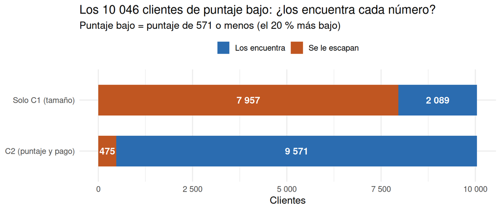

```r
cobertura[1:2, ] |>
  select(decide_con, `Los encuentra` = los_encuentra, `Se le escapan` = se_le_escapan) |>
  pivot_longer(-decide_con) |>
  mutate(decide_con = factor(decide_con, levels = rev(cobertura$decide_con[1:2]))) |>
  ggplot(aes(value, decide_con, fill = name)) +
  geom_col(width = 0.6) +
  geom_text(aes(label = miles(value)), position = position_stack(vjust = 0.5),
            color = "white", fontface = "bold", size = 4.3) +
  scale_fill_manual(values = c("#2B6CB0", "#C05621"), name = NULL) +
  scale_x_continuous(labels = miles) +
  labs(title = paste0("Los ", miles(sum(riesgo)), " clientes de puntaje bajo: ¿los encuentra cada número?"),
       subtitle = paste0("Puntaje bajo = puntaje de ", corte_puntaje, " o menos (el 20 % más bajo)"),
       x = "Clientes", y = NULL) +
  theme(legend.position = "top")
```

Ahora los **casos concretos**. Primero, los clientes que el índice de tamaño pondría entre los mejores (el 20 % más grande) pero que tienen puntaje bajo, ordenados de más a menos «grandes»:

```r
cand <- which(riesgo & pct_c1 >= 0.80)
top5 <- cand[order(-sc[cand, "C1"])][1:5]
data.frame(cliente = datos$id_cliente[top5],
           cupo = miles(datos$Credit_Limit[top5]),
           puntaje = datos$Credit_Score[top5],
           proporcion_pagada = round(datos$Payment_Ratio[top5], 2),
           uso_del_cupo = round(datos$Credit_Utilization[top5], 2),
           posicion_en_tamano = paste0("entre el ", coma(100 * (1 - pct_c1[top5]), 1), " % más grande"))
```

| cliente | cupo | puntaje | proporcion_pagada | uso_del_cupo | posicion_en_tamano |
| --- | --- | --- | --- | --- | --- |
| CC109672 | 6 411 000 | 571 | 0.98 | 0.89 | entre el 0,0 % más grande |
| CC101216 | 5 728 000 | 556 | 0.87 | 0.94 | entre el 0,0 % más grande |
| CC127457 | 5 141 000 | 498 | 0.56 | 0.88 | entre el 0,0 % más grande |
| CC106849 | 4 875 000 | 471 | 0.49 | 0.94 | entre el 0,0 % más grande |
| CC128561 | 5 703 000 | 542 | 0.56 | 0.77 | entre el 0,1 % más grande |

```r
# Y, de toda la cartera, quién queda peor representado por C1 solo
Z    <- scale(X)
Zhat <- pca$x[, 1, drop = FALSE] %*% t(pca$rotation[, 1, drop = FALSE])
err  <- rowSums((Z - Zhat)^2)                 # lo que C1 no alcanza a mostrar de cada cliente
sin_ver <- err / rowSums(Z^2)                 # fracción de lo que distingue al cliente que C1 no muestra
peor <- order(-err)[1:5]
data.frame(cliente = datos$id_cliente[peor],
           cupo = miles(datos$Credit_Limit[peor]),
           puntaje = datos$Credit_Score[peor],
           proporcion_pagada = round(datos$Payment_Ratio[peor], 2),
           de_cada_100_que_C1_no_muestra = round(100 * sin_ver[peor]))
```

|  | cliente | cupo | puntaje | proporcion_pagada | de_cada_100_que_C1_no_muestra |
| --- | --- | --- | --- | --- | --- |
| 42117 | CC142116 | 520 000 | 399 | 0.15 | 94 |
| 9810 | CC109809 | 4 488 000 | 391 | 0.13 | 46 |
| 42743 | CC142742 | 526 000 | 397 | 0.17 | 94 |
| 32013 | CC132012 | 986 000 | 390 | 0.16 | 79 |
| 35654 | CC135653 | 866 000 | 392 | 0.11 | 76 |

```r
c(riesgo = round(100 * mean(sin_ver[riesgo])), resto = round(100 * mean(sin_ver[!riesgo])))
```

```
## riesgo  resto
##     62     51
```

```r
n_gr <- length(cand)
```

# 5 Los perfiles en el plano

```r
mapa <- data.frame(C1 = sc[, "C1"], C2 = sc[, "C2"])

# Correlación de cada variable con C1 y C2: son las coordenadas de las flechas
fl <- as.data.frame(t(cor(sc[, 1:2], X)))
colnames(fl) <- c("C1", "C2")
fl$variable <- rownames(fl)
fl$etiqueta <- unname(etiqueta[fl$variable])
fl$bloque   <- factor(unname(bloque[fl$variable]), levels = c("Dinero", "Uso de la tarjeta", "Puntaje"))
fl$largo    <- sqrt(fl$C1^2 + fl$C2^2)    # 1 = la variable se ve entera en el mapa

ang <- function(a, b) acos(pmin(1, pmax(-1, sum(a * b) / sqrt(sum(a^2) * sum(b^2))))) * 180 / pi
M <- as.matrix(fl[, c("C1", "C2")]); rownames(M) <- fl$variable
A <- outer(1:p, 1:p, Vectorize(function(i, j) ang(M[i, ], M[j, ])))
dimnames(A) <- list(fl$variable, fl$variable)
```

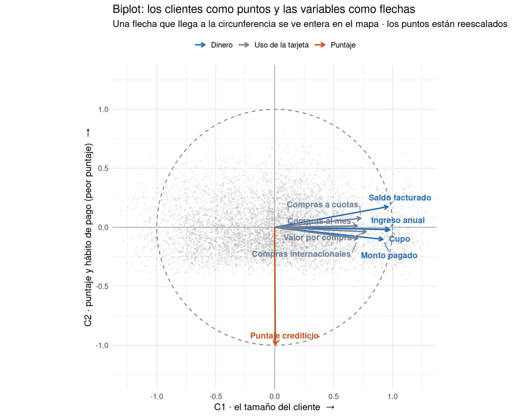

```r
set.seed(2026)
idx <- sample(nrow(mapa), 6000)                                   # solo para que el gráfico sea liviano
esc <- unname(1.1 / quantile(abs(as.vector(sc[, 1:2])), 0.99))    # reescala los puntos para que quepan
nube <- data.frame(x = mapa$C1[idx] * esc, y = mapa$C2[idx] * esc)
t_c <- seq(0, 2 * pi, length.out = 200)
circulo <- data.frame(x = cos(t_c), y = sin(t_c))

ggplot() +
  geom_point(data = nube, aes(x, y), alpha = 0.12, size = 0.5, color = "grey60") +
  geom_path(data = circulo, aes(x, y), color = "grey50", linetype = "dashed") +
  geom_hline(yintercept = 0, color = "grey70") +
  geom_vline(xintercept = 0, color = "grey70") +
  geom_segment(data = fl, aes(x = 0, y = 0, xend = C1, yend = C2, color = bloque),
               arrow = arrow(length = unit(0.22, "cm")), linewidth = 0.9) +
  geom_text_repel(data = fl, aes(C1, C2, label = etiqueta, color = bloque),
                  size = 4, fontface = "bold", box.padding = 0.5, point.padding = 0.3,
                  min.segment.length = 0, max.overlaps = Inf, seed = 1, show.legend = FALSE) +
  scale_color_manual(values = c("Dinero" = "#2B6CB0", "Uso de la tarjeta" = "#718096", "Puntaje" = "#C05621"),
                     name = NULL) +
  coord_fixed(xlim = c(-1.25, 1.25), ylim = c(-1.25, 1.25)) +
  labs(title = "Biplot: los clientes como puntos y las variables como flechas",
       subtitle = "Una flecha que llega a la circunferencia se ve entera en el mapa · los puntos están reescalados",
       x = "C1 · el tamaño del cliente  →", y = "C2 · puntaje y hábito de pago (peor puntaje)  →") +
  theme(legend.position = "top")
```

```r
data.frame(variable = fl$etiqueta, bloque = fl$bloque,
           angulo_desde_C1 = round(atan2(fl$C2, fl$C1) * 180 / pi),
           largo_de_la_flecha = round(fl$largo, 2),
           de_cada_100_que_se_ve_en_el_mapa = round(100 * fl$largo^2))
```

| variable | bloque | angulo_desde_C1 | largo_de_la_flecha | de_cada_100_que_se_ve_en_el_mapa |
| --- | --- | --- | --- | --- |
| Ingreso anual | Dinero | -1 | 0.97 | 94 |
| Cupo | Dinero | -1 | 0.98 | 96 |
| Saldo facturado | Dinero | 10 | 0.98 | 95 |
| Monto pagado | Dinero | -6 | 0.92 | 85 |
| Compras a cuotas | Uso de la tarjeta | 6 | 0.73 | 54 |
| Compras al mes | Uso de la tarjeta | 1 | 0.70 | 49 |
| Valor por compra | Uso de la tarjeta | -3 | 0.78 | 60 |
| Compras internacionales | Uso de la tarjeta | -8 | 0.71 | 51 |
| Puntaje crediticio | Puntaje | -90 | 1.00 | 99 |

```r
sub_dinero     <- A[dinero, dinero][upper.tri(A[dinero, dinero])]
ang_pun_dinero <- A["Credit_Score", dinero]
min_ang        <- apply(A + diag(999, p), 1, min)        # ángulo a la flecha más cercana
sola_b         <- names(which.max(min_ang))
mas_abierta    <- rownames(A)[which(A == max(A), arr.ind = TRUE)[1, ]]
pobres         <- unname(etiqueta[fl$variable[fl$largo < 0.7]])
```

Ahora los **casos**. Tomamos un cliente cualquiera, su vecino más cercano en el plano y el cliente más alejado del comportamiento general:

```r
set.seed(2026)
i <- sample(nrow(mapa), 1)
d_i <- sqrt((mapa$C1 - mapa$C1[i])^2 + (mapa$C2 - mapa$C2[i])^2)
j <- order(d_i)[2]                                        # el más cercano a i (el 1.º es i mismo)

md <- mahalanobis(mapa, colMeans(mapa), cov(mapa))        # qué tan lejos está cada cliente del centro
lejos <- md > qchisq(0.999, 2)
k <- which.max(md)

ver <- function(ix, rotulo) data.frame(caso = rotulo, cliente = datos$id_cliente[ix],
  cupo = miles(datos$Credit_Limit[ix]), saldo = miles(datos$Statement_Balance[ix]),
  puntaje = datos$Credit_Score[ix], proporcion_pagada = round(datos$Payment_Ratio[ix], 2),
  uso_del_cupo = round(datos$Credit_Utilization[ix], 2), C1 = round(mapa$C1[ix], 2), C2 = round(mapa$C2[ix], 2))
rbind(ver(i, "Cliente cualquiera"), ver(j, "Su vecino más cercano en el mapa"), ver(k, "El más alejado del conjunto"))
```

| caso | cliente | cupo | saldo | puntaje | proporcion_pagada | uso_del_cupo | C1 | C2 |
| --- | --- | --- | --- | --- | --- | --- | --- | --- |
| Cliente cualquiera | CC136472 | 556 000 | 123 096 | 659 | 0.72 | 0.13 | 0.67 | -0.48 |
| Su vecino más cercano en el mapa | CC110768 | 463 000 | 219 518 | 666 | 0.96 | 0.36 | 0.66 | -0.47 |
| El más alejado del conjunto | CC106265 | 686 000 | 702 241 | 372 | 0.18 | 0.92 | 1.54 | 4.02 |

```r
# Los 5 más alejados, para ver qué los aleja
lejanos <- order(-md)[1:5]
rbind(ver(lejanos[1], "1.º"), ver(lejanos[2], "2.º"), ver(lejanos[3], "3.º"), ver(lejanos[4], "4.º"), ver(lejanos[5], "5.º"))
```

| caso | cliente | cupo | saldo | puntaje | proporcion_pagada | uso_del_cupo | C1 | C2 |
| --- | --- | --- | --- | --- | --- | --- | --- | --- |
| 1.º | CC106265 | 686 000 | 702 241 | 372 | 0.18 | 0.92 | 1.54 | 4.02 |
| 2.º | CC118646 | 552 000 | 536 169 | 367 | 0.18 | 0.88 | 0.56 | 4.03 |
| 3.º | CC123061 | 6 335 000 | 5 053 556 | 404 | 0.15 | 0.71 | 5.40 | 3.32 |
| 4.º | CC142865 | 17 000 | 20 115 | 407 | 0.21 | 0.92 | -5.71 | 3.23 |
| 5.º | CC109809 | 4 488 000 | 4 543 151 | 391 | 0.13 | 0.93 | 4.86 | 3.47 |

```r
c(clientes_alejados_del_comportamiento_general = sum(lejos), de_cada_100 = round(100 * mean(lejos), 2))
```

```
## clientes_alejados_del_comportamiento_general
##                                        22.00
##                                  de_cada_100
##                                         0.04
```

- 👀 **Qué vemos:** el cliente CC136472 y su vecino CC110768 están a 0,02 unidades en el mapa y tienen cupos de 556 000 y 463 000, puntajes de 659 y 666. Quedan 22 clientes (0,04 de cada 100) muy alejados del comportamiento general; el más alejado es el CC106265, con cupo de 686 000 y puntaje de 372.
- 💼 **Qué significa para el cliente:** clientes cercanos en el mapa tienen una ficha parecida, y la Gerencia puede tratarlos de forma parecida; los alejados son extremos (mucho dinero o un puntaje muy fuera de lo normal) y conviene mirarlos uno a uno, sin esperar que se parezcan a nadie.
- ✅ **Qué decide el cliente:** revisar a mano esa lista corta de extremos, y usar la posición en el mapa para agrupar al resto.

## 5.1 Un grupo que le importa al cliente: los grandes y de riesgo

```r
corte_c1 <- quantile(mapa$C1, 0.80)
corte_c2 <- quantile(mapa$C2, 0.80)
en_A <- mapa$C1 >= corte_c1 & mapa$C2 >= corte_c2      # arriba a la derecha: grande y de riesgo

resumen_A <- function(m, nombre) data.frame(
  grupo = nombre,
  clientes = miles(sum(m)),
  de_cada_100_de_la_cartera = round(100 * mean(m), 1),
  con_puntaje_bajo = miles(sum(m & riesgo)),
  cupo_promedio = miles(mean(datos$Credit_Limit[m])),
  puntaje_promedio = round(mean(datos$Credit_Score[m])),
  proporcion_pagada = round(mean(datos$Payment_Ratio[m]), 2),
  uso_del_cupo = round(mean(datos$Credit_Utilization[m]), 2),
  saldo_facturado_millones = miles(sum(datos$Statement_Balance[m]) / 1e6))
rbind(resumen_A(en_A, "A · grande y de riesgo"), resumen_A(!en_A, "Resto de la cartera"))
```

| grupo | clientes | de_cada_100_de_la_cartera | con_puntaje_bajo | cupo_promedio | puntaje_promedio | proporcion_pagada | uso_del_cupo | saldo_facturado_millones |
| --- | --- | --- | --- | --- | --- | --- | --- | --- |
| A · grande y de riesgo | 1 766 | 3.5 | 1 704 | 2 074 561 | 524 | 0.47 | 0.63 | 2 497 |
| Resto de la cartera | 48 234 | 96.5 | 8 342 | 659 705 | 633 | 0.77 | 0.42 | 15 812 |

```r
saldo_A <- 100 * sum(datos$Statement_Balance[en_A]) / sum(datos$Statement_Balance)
```

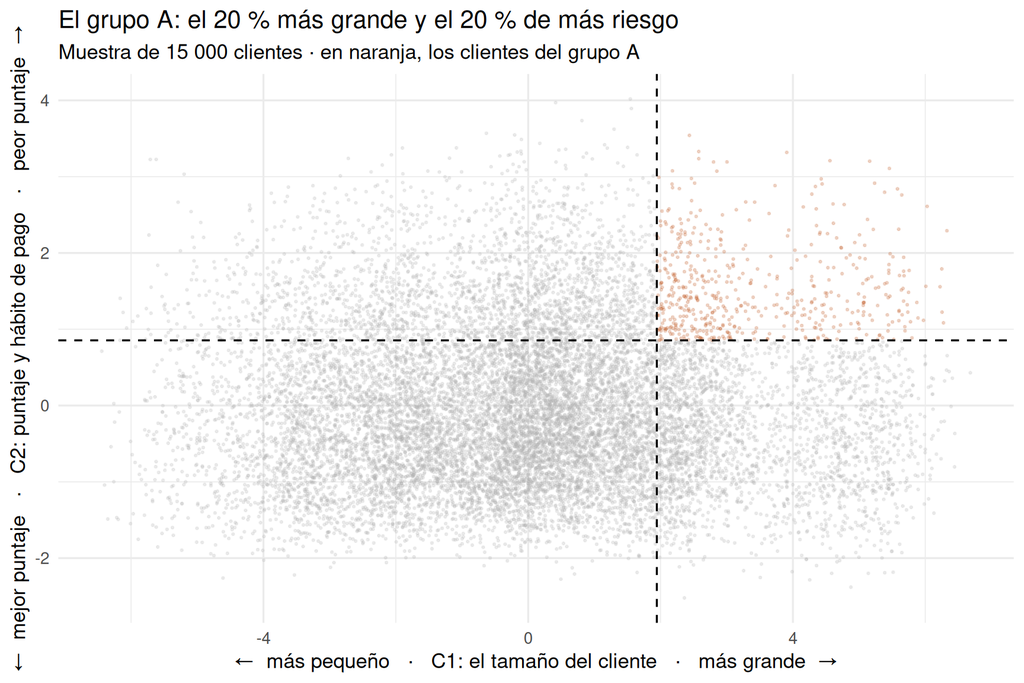

```r
set.seed(2026)
mu <- sample(nrow(mapa), 15000)
ggplot(mapa[mu, ], aes(C1, C2, color = en_A[mu])) +
  geom_point(alpha = 0.2, size = 0.4) +
  geom_vline(xintercept = corte_c1, linetype = "dashed") +
  geom_hline(yintercept = corte_c2, linetype = "dashed") +
  scale_color_manual(values = c("FALSE" = "grey70", "TRUE" = "#C05621"), guide = "none") +
  labs(title = "El grupo A: el 20 % más grande y el 20 % de más riesgo",
       subtitle = "Muestra de 15 000 clientes · en naranja, los clientes del grupo A",
       x = "←  más pequeño   ·   C1: el tamaño del cliente   ·   más grande  →",
       y = "←  mejor puntaje   ·   C2: puntaje y hábito de pago   ·   peor puntaje  →")
```

- 👀 **Qué vemos:** el grupo A (arriba a la derecha) reúne 1 766 clientes. Tienen un cupo promedio de 2 074 561 ₹ (resto: 659 705), pagan 0,47 de lo facturado (resto: 0,77) y usan 0,63 del cupo (resto: 0,42); concentran 14 de cada 100 ₹ facturadas en toda la cartera.
- 💼 **Qué significa para el cliente:** son clientes **grandes que pagan poco de lo que deben**: el índice de tamaño los trataría como los mejores, pero cada llamada a este grupo protege mucho más dinero que una llamada al resto. La proporción pagada y el uso del cupo no entraron al mapa, y aun así confirman que la zona es de riesgo; eso es más honesto que mirar el puntaje, que sí ayudó a construir el eje. No decimos que ser grande cause un mal pago, solo que ambas cosas aparecen juntas.
- ✅ **Qué decide el cliente:** empezar el seguimiento preventivo por el grupo A (gestor dedicado, congelar aumentos de cupo y ofrecer refinanciación), y sumar a los de riesgo que no son grandes si la capacidad del equipo lo permite. El corte del 20 % es una decisión de la Gerencia, no un borde que el mapa haya encontrado.

# 6 Lo común y lo propio

Pasamos del resumen (**qué guarda más información**) al análisis factorial (**qué comparten las variables y qué conserva información propia**). Trabajamos con las mismas 9 variables (con logaritmo donde corresponde), con los nombres en español.

```r
XE <- X; colnames(XE) <- etiqueta[vars]
R_e <- cor(XE)

fa1 <- fa(XE, nfactors = 1, fm = "ml")
carga1 <- fa1$loadings[, 1]
if (sum(carga1) < 0) carga1 <- -carga1       # el signo es arbitrario: más capacidad = positivo

partes <- data.frame(variable = names(carga1), carga = round(carga1, 3),
                     comun = round(100 * carga1^2, 1), propia = round(100 - 100 * carga1^2, 1), row.names = NULL)
partes <- partes[order(-partes$comun), ]
partes
```

|  | variable | carga | comun | propia |
| --- | --- | --- | --- | --- |
| 2 | Cupo | 0.996 | 99.1 | 0.9 |
| 1 | Ingreso anual | 0.987 | 97.5 | 2.5 |
| 3 | Saldo facturado | 0.946 | 89.6 | 10.4 |
| 4 | Monto pagado | 0.886 | 78.5 | 21.5 |
| 7 | Valor por compra | 0.772 | 59.7 | 40.3 |
| 6 | Compras al mes | 0.676 | 45.7 | 54.3 |
| 5 | Compras a cuotas | 0.666 | 44.3 | 55.7 |
| 8 | Compras internacionales | 0.654 | 42.7 | 57.3 |
| 9 | Puntaje crediticio | 0.018 | 0.0 | 100.0 |

```r
comun_total <- 100 * sum(carga1^2) / p
```

La **carga** es la correlación de cada variable con la dimensión común; su cuadrado es la **parte común** (de cada 100 partes de las diferencias entre clientes en esa variable, cuántas vienen de lo compartido). Lo que falta para 100 es la **parte propia**.

## 6.1 ¿Cuánto comparte cada variable?

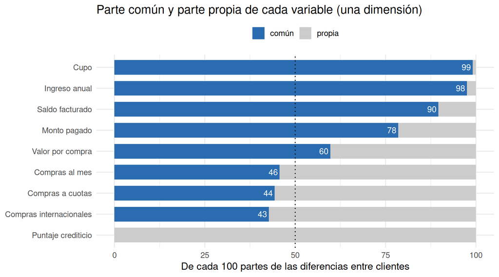

```r
largo <- rbind(data.frame(variable = partes$variable, parte = "común", valor = partes$comun),
               data.frame(variable = partes$variable, parte = "propia", valor = partes$propia))
largo$variable <- factor(largo$variable, levels = rev(partes$variable))
largo$parte <- factor(largo$parte, levels = c("propia", "común"))

ggplot(largo, aes(valor, variable, fill = parte)) +
  geom_col(width = 0.7) +
  geom_text(data = subset(largo, parte == "común" & valor > 8),
            aes(label = coma(valor, 0)), hjust = 1.2, colour = "white", size = 3.8) +
  scale_fill_manual(values = c("común" = "#2B6CB0", "propia" = "grey80"), breaks = c("común", "propia")) +
  geom_vline(xintercept = 50, linetype = 3) +
  labs(x = "De cada 100 partes de las diferencias entre clientes", y = NULL, fill = NULL,
       title = "Parte común y parte propia de cada variable (una dimensión)") +
  theme(legend.position = "top")
```

```r
cp <- function(v) partes$comun[partes$variable == v]
comun_uso <- partes$comun[partes$variable %in% etiqueta[uso]]
```

- 👀 **Qué vemos:** la dimensión común explica 99 de cada 100 del cupo y 98 del ingreso, 90 del saldo, 78 del pago, entre 43 y 60 de las de uso y solo 0 del puntaje. En total reúne 61,9 de cada 100 partes de la ficha.
- 💼 **Qué significa para el cliente:** lo que comparten las variables de dinero puede leerse como una **capacidad económica** común (nombre nuestro, leído de las variables que más cargan; el modelo no la mide ni demuestra que exista como tal); en las variables de uso, buena parte de lo que cada una dice es propio, y del puntaje casi todo lo es.
- ✅ **Qué decide el cliente:** para medir capacidad le bastan ingreso y cupo; las variables de uso y el puntaje debe mirarlos aparte.

## 6.2 ¿Alcanza una sola dimensión?

Si una sola dimensión explicara todo lo que las variables comparten, la correlación entre dos variables sería el **producto de sus cargas**. Comparamos cada correlación observada con la que reproduce el modelo.

```r
pares <- which(upper.tri(R_e), arr.ind = TRUE)
comparacion <- data.frame(var_1 = rownames(R_e)[pares[, 1]], var_2 = colnames(R_e)[pares[, 2]],
                          observada = R_e[pares],
                          reproducida = carga1[pares[, 1]] * carga1[pares[, 2]])
comparacion$diferencia <- comparacion$observada - comparacion$reproducida
comparacion <- comparacion[order(-abs(comparacion$diferencia)), ]
rownames(comparacion) <- NULL
comparacion$par <- paste(comparacion$var_1, "–", comparacion$var_2)

n_bien <- sum(abs(comparacion$diferencia) < 0.05)
n_mal  <- sum(abs(comparacion$diferencia) > 0.10)
rmsr   <- sqrt(mean(comparacion$diferencia^2))
peor_par <- comparacion[1, ]

c(pares = nrow(comparacion), con_diferencia_menor_a_0.05 = n_bien, con_diferencia_mayor_a_0.10 = n_mal,
  raiz_del_error_cuadratico_medio = round(rmsr, 3))
```

```
##                           pares     con_diferencia_menor_a_0.05
##                           36.00                           31.00
##     con_diferencia_mayor_a_0.10 raiz_del_error_cuadratico_medio
##                            3.00                            0.07
```

```r
transform(head(comparacion[, 1:5], 6), observada = round(observada, 3),
          reproducida = round(reproducida, 3), diferencia = round(diferencia, 3))
```

|  | var_1 | var_2 | observada | reproducida | diferencia |
| --- | --- | --- | --- | --- | --- |
| 1 | Compras al mes | Valor por compra | 0.201 | 0.522 | -0.321 |
| 2 | Saldo facturado | Puntaje crediticio | -0.169 | 0.017 | -0.186 |
| 3 | Compras a cuotas | Compras al mes | 0.565 | 0.450 | 0.116 |
| 4 | Saldo facturado | Monto pagado | 0.933 | 0.839 | 0.095 |
| 5 | Monto pagado | Puntaje crediticio | 0.108 | 0.016 | 0.093 |
| 6 | Compras a cuotas | Puntaje crediticio | -0.028 | 0.012 | -0.040 |

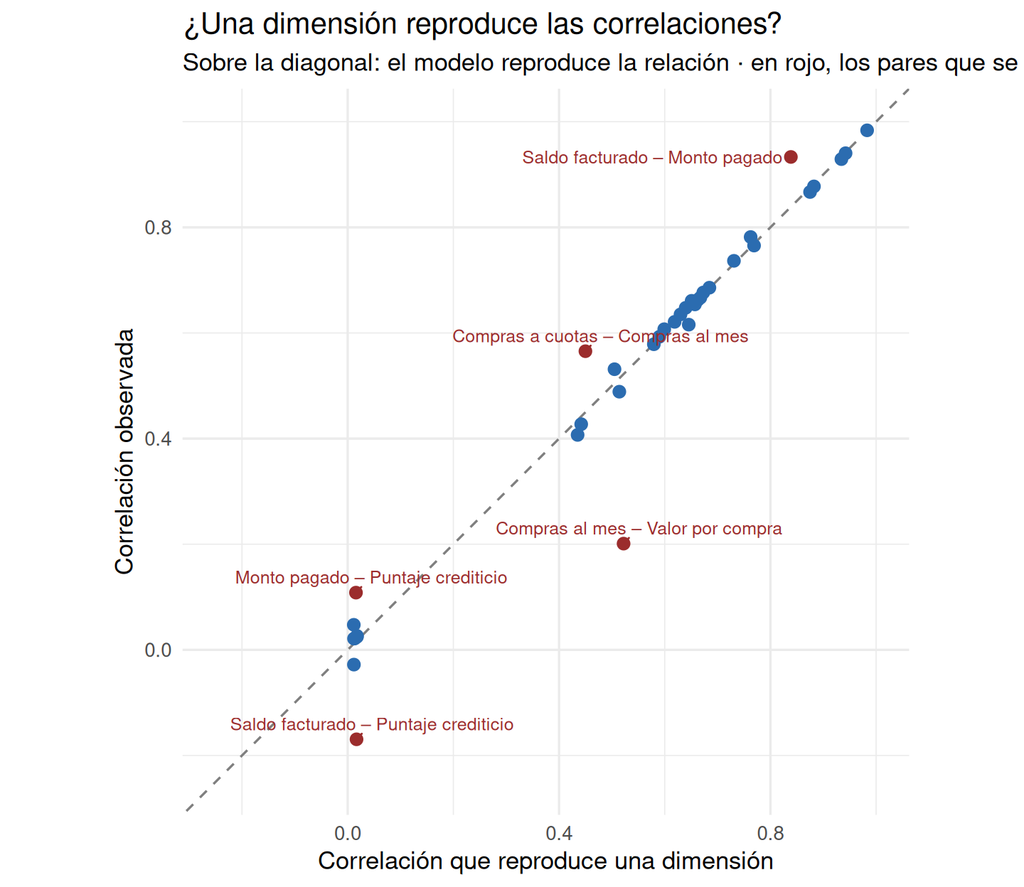

```r
ggplot(comparacion, aes(reproducida, observada)) +
  geom_abline(slope = 1, intercept = 0, linetype = 2, colour = "grey50") +
  geom_point(aes(colour = abs(diferencia) > 0.08), size = 2.6) +
  geom_text_repel(data = subset(comparacion, abs(diferencia) > 0.08),
                  aes(label = par), size = 3.3, colour = "#9B2C2C", min.segment.length = 0) +
  scale_colour_manual(values = c("FALSE" = "#2B6CB0", "TRUE" = "#9B2C2C"), guide = "none") +
  coord_equal(xlim = c(-0.25, 1), ylim = c(-0.25, 1)) +
  labs(x = "Correlación que reproduce una dimensión", y = "Correlación observada",
       title = "¿Una dimensión reproduce las correlaciones?",
       subtitle = "Sobre la diagonal: el modelo reproduce la relación · en rojo, los pares que se apartan")
```

- 👀 **Qué vemos:** 31 de los 36 pares quedan a menos de 0,05 de lo que reproduce el modelo y 3 se apartan más de 0,10; el promedio de error es 0,070. **El error más grande** es **compras al mes – valor por compra**: la correlación observada es 0,20 y el modelo reproduce 0,52 (diferencia -0,32).
- 💼 **Qué significa para el cliente:** una sola dimensión reproduce bien la mayoría de las relaciones, pero no todas. Lo que falla está en los pares de la tabla de arriba: ahí las variables se parecen o se contraponen más de lo que la capacidad común explica, y eso es conducta (cómo se gasta, cómo se paga), no tamaño.
- ✅ **Qué decide el cliente:** usar la capacidad común para el bloque de dinero, y no suponer que explica todo: conviene probar con dos dimensiones antes de dar la estructura por cerrada.

## 6.3 ¿Qué variable conserva más información propia?

```r
mas_propia <- partes$variable[which.max(partes$propia)]
partes[partes$variable == mas_propia, ]
```

|  | variable | carga | comun | propia |
| --- | --- | --- | --- | --- |
| 9 | Puntaje crediticio | 0.018 | 0 | 100 |

```r
r2_resto <- unname(smc(R_e)[mas_propia])    # cuánto de esa variable predicen las otras 8 juntas
pred_tam <- setdiff(colnames(XE), c(mas_propia, "Saldo facturado", "Monto pagado"))
r2_sin_pago <- summary(lm(reformulate(sprintf("`%s`", pred_tam), response = sprintf("`%s`", mas_propia)),
                          data = XE))$r.squared
c(R2_con_las_otras_8 = round(r2_resto, 3), R2_sin_saldo_ni_pago = round(r2_sin_pago, 3))
```

```
##   R2_con_las_otras_8 R2_sin_saldo_ni_pago
##                0.890                0.006
```

- 👀 **Qué vemos:** la variable con más información propia es el **puntaje crediticio**: 100,0 de cada 100 son propias (carga 0,018). Las otras ocho variables, juntas, predicen 89 de cada 100 de ella, y sin saldo ni pago apenas 0,6.
- 💼 **Qué significa para el cliente:** esta variable representa **qué tan buen pagador es el cliente y cómo lo ve el buró**, algo que el tamaño no dice. No debería desaparecer dentro de un indicador general: su parte propia **no es solo error de medición**, porque saldo, pago y cupo, combinados, sí la predicen en buena parte.
- ✅ **Qué decide el cliente:** si resume la ficha en un índice de capacidad, ignorar esta variable cambiaría la lista de seguimiento (los grandes con puntaje bajo pasarían por buenos clientes); debe entrar **por su cuenta** a la decisión.

# 7 ¿Dos dimensiones con nombre?

## 7.1 ¿Cuántas dimensiones caben?

Con 9 variables, un modelo de `k` dimensiones solo se puede estimar si tiene grados de libertad no negativos: `((p − k)² − (p + k)) / 2 ≥ 0`. Los **grados de libertad** son las relaciones entre variables que sobran después de estimar el modelo: si son negativos, el modelo tendría más cosas por estimar que relaciones con las cuales estimarlas.

```r
kk <- 1:6
gl <- ((p - kk)^2 - (p + kk)) / 2
data.frame(dimensiones = kk, grados_de_libertad = gl, variables_por_dimension = round(p / kk, 1),
           se_puede_estimar = ifelse(gl >= 0, "sí", "no"))
```

| dimensiones | grados_de_libertad | variables_por_dimension | se_puede_estimar |
| --- | --- | --- | --- |
| 1 | 27 | 9.0 | sí |
| 2 | 19 | 4.5 | sí |
| 3 | 12 | 3.0 | sí |
| 4 | 6 | 2.2 | sí |
| 5 | 1 | 1.8 | sí |
| 6 | -3 | 1.5 | no |

```r
k_max <- max(kk[gl >= 0])
```

- 👀 **Qué vemos:** con 9 variables se pueden estimar hasta 5 dimensiones; con 2 sobran 19 grados de libertad y quedan 4,5 variables por dimensión.
- 💼 **Qué significa para el cliente:** que el modelo se pueda calcular no quiere decir que cada dimensión tenga sentido: una dimensión necesita varias variables que carguen en ella (idealmente tres o más).
- ✅ **Qué decide el cliente:** dos dimensiones caben con nuestras variables, así que las estimamos y juzgamos después si son interpretables.

## 7.2 Dos dimensiones

La rotación **oblimin** reacomoda las dimensiones para que cada variable cargue sobre todo en una, y les permite estar relacionadas entre sí (no las obliga a ser independientes).

```r
fa2 <-fa(XE, nfactors = 2, fm = "ml", rotate = "oblimin")

# Pone primero la dimensión que más carga en el cupo (la «capacidad»), con signo positivo
alinear_fa <- function(m) {
  L <- unclass(m$loadings)[, 1:2, drop = FALSE]
  f_cap <- which.max(abs(L["Cupo", ]))
  ord <- c(f_cap, setdiff(1:2, f_cap))
  L <- L[, ord]
  s <- c(sign(L["Cupo", 1]), sign(L[which.max(abs(L[, 2])), 2]))
  L <- sweep(L, 2, s, `*`)
  colnames(L) <- c("F1", "F2")
  Phi <- m$Phi[ord, ord] * outer(s, s)
  list(L = L, phi = Phi[1, 2])
}
a_ml <- alinear_fa(fa2)
L2 <- a_ml$L; phi2 <- a_ml$phi

data.frame(variable = rownames(L2), F1 = round(L2[, 1], 3), F2 = round(L2[, 2], 3),
           parte_comun_con_2_dimensiones = round(100 * fa2$communality[rownames(L2)], 1), row.names = NULL)
```

| variable | F1 | F2 | parte_comun_con_2_dimensiones |
| --- | --- | --- | --- |
| Ingreso anual | 0.987 | 0.025 | 97.5 |
| Cupo | 0.994 | 0.026 | 98.9 |
| Saldo facturado | 0.952 | -0.170 | 93.7 |
| Monto pagado | 0.891 | 0.107 | 80.4 |
| Compras a cuotas | 0.666 | -0.028 | 44.5 |
| Compras al mes | 0.676 | 0.021 | 45.7 |
| Valor por compra | 0.773 | 0.022 | 59.8 |
| Compras internacionales | 0.652 | 0.047 | 42.7 |
| Puntaje crediticio | 0.003 | 0.998 | 99.5 |

```r
c(correlacion_entre_dimensiones = round(phi2, 3))
```

```
## correlacion_entre_dimensiones
##                        -0.003
```

```r
f1_vars <- rownames(L2)[abs(L2[, 1]) > 0.30]
f2_vars <- rownames(L2)[abs(L2[, 2]) > 0.30]
f2_una  <- length(f2_vars) == 1
```

- 👀 **Qué vemos:** la primera dimensión la forman ingreso anual, cupo, saldo facturado, monto pagado, compras a cuotas, compras al mes, valor por compra y compras internacionales (cargas de más de 0,3) y la segunda, puntaje crediticio. Las dos dimensiones se correlacionan -0,00.
- 💼 **Qué significa para el cliente:** la segunda dimensión **no es una dimensión con sentido**: es una sola variable (puntaje crediticio) con otro nombre, y que su parte común suba solo quiere decir que el modelo le dio una dimensión para ella sola. Una dimensión necesita al menos dos o tres variables que carguen en ella; por eso **no le ponemos nombre**. La primera sí tiene una lectura clara: **capacidad económica** (nombre nuestro, por las variables de dinero que cargan en ella). Las dos dimensiones casi no se relacionan, aunque la rotación oblimin les permitía hacerlo: aquí se pueden tratar como casi independientes.
- ✅ **Qué decide el cliente:** mantener la misma recomendación: una capacidad común y el puntaje por separado; llamar «riesgo financiero» a la segunda dimensión sería inventar una dimensión donde hay una sola variable.

## 7.3 ¿Son estables?

Repetimos el análisis cambiando **solo** el método de estimación a `fm = "minres"`.

```r
fa2m <- fa(XE, nfactors = 2, fm = "minres", rotate = "oblimin")
a_mr <- alinear_fa(fa2m)

comparar <- data.frame(variable = rownames(a_ml$L),
                       ml_F1 = round(a_ml$L[, 1], 3), ml_F2 = round(a_ml$L[, 2], 3),
                       minres_F1 = round(a_mr$L[, 1], 3), minres_F2 = round(a_mr$L[, 2], 3), row.names = NULL)
comparar
```

| variable | ml_F1 | ml_F2 | minres_F1 | minres_F2 |
| --- | --- | --- | --- | --- |
| Ingreso anual | 0.987 | 0.025 | 0.982 | 0.029 |
| Cupo | 0.994 | 0.026 | 0.996 | 0.032 |
| Saldo facturado | 0.952 | -0.170 | 0.979 | -0.163 |
| Monto pagado | 0.891 | 0.107 | 0.910 | 0.099 |
| Compras a cuotas | 0.666 | -0.028 | 0.675 | -0.024 |
| Compras al mes | 0.676 | 0.021 | 0.644 | 0.014 |
| Valor por compra | 0.773 | 0.022 | 0.731 | 0.023 |
| Compras internacionales | 0.652 | 0.047 | 0.648 | 0.050 |
| Puntaje crediticio | 0.003 | 0.998 | 0.003 | 0.998 |

```r
c(correlacion_entre_dimensiones_ml = round(a_ml$phi, 3), correlacion_entre_dimensiones_minres = round(a_mr$phi, 3))
```

```
##     correlacion_entre_dimensiones_ml correlacion_entre_dimensiones_minres
##                               -0.003                               -0.005
```

```r
cong <- sapply(1:2, function(j) sum(a_ml$L[, j] * a_mr$L[, j]) / sqrt(sum(a_ml$L[, j]^2) * sum(a_mr$L[, j]^2)))
dif_max <- max(abs(a_ml$L - a_mr$L))
asigna <- function(L) apply(abs(L), 1, which.max)
mismas <- mean(asigna(a_ml$L) == asigna(a_mr$L))
estable <- all(cong > 0.95) && mismas == 1 && dif_max < 0.10
c(congruencia_F1 = round(cong[1], 3), congruencia_F2 = round(cong[2], 3),
  mayor_diferencia_de_cargas = round(dif_max, 3), variables_que_siguen_en_la_misma_dimension = mismas)
```

```
##                             congruencia_F1
##                                      1.000
##                             congruencia_F2
##                                      1.000
##                 mayor_diferencia_de_cargas
##                                      0.042
## variables_que_siguen_en_la_misma_dimension
##                                      1.000
```

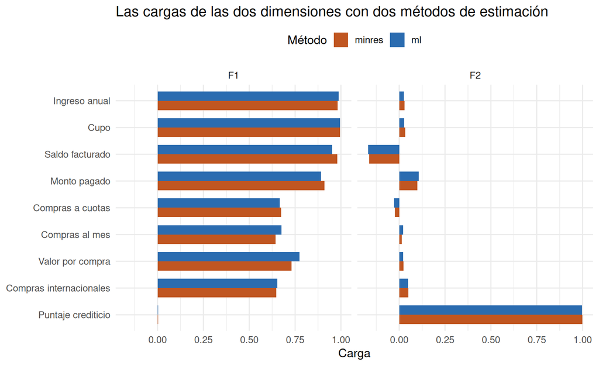

```r
bind_rows(
  data.frame(metodo = "ml", variable = rownames(a_ml$L), F1 = a_ml$L[, 1], F2 = a_ml$L[, 2]),
  data.frame(metodo = "minres", variable = rownames(a_mr$L), F1 = a_mr$L[, 1], F2 = a_mr$L[, 2])) |>
  pivot_longer(c(F1, F2), names_to = "dimension", values_to = "carga") |>
  mutate(variable = factor(variable, levels = rev(rownames(a_ml$L)))) |>
  ggplot(aes(carga, variable, fill = metodo)) +
  geom_col(position = "dodge", width = 0.7) +
  facet_wrap(~ dimension) +
  scale_fill_manual(values = c("ml" = "#2B6CB0", "minres" = "#C05621"), name = "Método") +
  labs(title = "Las cargas de las dos dimensiones con dos métodos de estimación",
       x = "Carga", y = NULL) +
  theme(legend.position = "top")
```

- 👀 **Qué vemos:** 100 de cada 100 variables siguen en la misma dimensión; la mayor diferencia entre una carga y la otra es 0,042; la correspondencia entre dimensiones (la «congruencia»: 1 si los dos métodos dan exactamente el mismo patrón de cargas, 0 si no se parecen en nada) es de 1,000 (primera) y 1,000 (segunda), y la correlación entre ellas pasa de -0,00 a -0,00.
- 💼 **Qué significa para el cliente:** la estructura es **estable**: con otro método, las mismas variables forman las mismas dimensiones y los pesos principales se mantienen, así que la lectura de la primera dimensión como capacidad económica se sostiene. Eso sí: que la segunda dimensión sea estable no la convierte en una dimensión con sentido, porque sigue siendo una sola variable.
- ✅ **Qué decide el cliente:** puede apoyarse en la capacidad económica como dimensión estable y dejar el puntaje aparte.

# 8 La recomendación al cliente

1. **¿Puede resumir sus datos en un número? ¿Qué representaría?** Sí, la ficha se resume en un número que representa **el tamaño del cliente** (cuánto gana, tiene y mueve), pero ese número no basta para decidir a quién llamar.
2. **¿Cuánta información conserva y qué deja por fuera?** Un número conserva 64 de cada 100 partes de la ficha y deja por fuera **el puntaje y el hábito de pago**: con él se le escapan 7 957 de los 10 046 clientes de puntaje bajo, y dos números conservan 76 de cada 100.
3. **¿Cuántas dimensiones parecen existir y qué debe analizar aparte?** Parece haber **una capacidad económica común** (62 de cada 100 partes de la ficha) y, por separado, el **puntaje crediticio**, con 100 de cada 100 propio; las variables de uso conservan buena parte de información propia y conviene seguirlas viendo aparte (el par que una dimensión peor explica es compras al mes – valor por compra: a igual capacidad, unos compran mucho y barato y otros poco y caro).
4. **¿Qué decisión recomendamos?** Reportar **dos números, tamaño y puntaje con hábito de pago**, y escoger para el seguimiento preventivo primero al grupo de clientes grandes y de riesgo (1 766 clientes, que concentran 14 de cada 100 ₹ facturadas y pagan solo 0,47 de lo facturado), y no por tamaño, que dejaría escapar a 79 de cada 100 clientes de puntaje bajo.

### Qué no sabemos todavía

- **No sabemos por qué.** Todo lo que vemos son variables que aparecen juntas. No podemos decir que ser grande cause un mal pago, ni que la capacidad económica cause el puntaje: los nombres de las componentes y de la dimensión son nuestros, no un hallazgo.
- **No sabemos qué pasará con clientes futuros.** El análisis describe a los 50 000 clientes de esta base en un momento; no predice quién caerá en mora ni qué pasa con clientes nuevos.
- **No sabemos si el puntaje bajo es mora.** Definimos «riesgo» como el 20 % de menor puntaje crediticio; la base no trae una variable de mora o incumplimiento con la que verificarlo, y el corte del 20 % es una decisión nuestra.
- **No sabemos qué variables nos faltan.** Los resultados dependen de las 9 variables escogidas; otras (historial de mora, producto contratado, canal de venta) podrían cambiar las dimensiones.
- **No sabemos si esto vale para otros bancos o carteras.** La base es sintética y las conclusiones hablan de ella, no de la población de tarjetas de crédito en general.
- **La segunda dimensión no es una dimensión con sentido** (es una sola variable), y la estabilidad se comprobó solo cambiando el método de estimación, no con otras muestras.